# Problem Set 2 - Solutions

Solution Key

2025-09-24

## 📊 The Challenge: The Global Widget Sales Dataset

**Estimated Time:** 60-75 minutes

You’ve have been hired as a data analyst role and are responsible for a dataset of **500 records**. Your task is to investigate and prepare this dataset for a predictive model that will forecast future sales. This assignment will test your skills in advanced exploratory data analysis (EDA), robust data cleaning, and sophisticated feature engineering.

First, let’s load the dataset.

```r
global_sales <- read_csv("ps2_sales_data.csv")
```

### Part 1: The Data is Dirty

You discover the dataset has inconsistencies that could lead to inaccurate analysis. Before moving forward, you need to apply robust data cleaning techniques.

**Question 1.1:** First, calculate the average `units_sold` by `product_category` without any cleaning. Then, use a function from `stringr` to standardize `product_category` into a single, consistent format and recalculate the averages. Compare the results to demonstrate why data cleaning matters.

```r
# Calculate averages with raw, uncleaned data
raw_averages <- global_sales %>%
  group_by(product_category) %>%
  summarise(avg_units_sold = mean(units_sold)) %>%
  arrange(product_category)

print("Raw averages (before cleaning):")
```

```
## [1] "Raw averages (before cleaning):"
```

```r
print(raw_averages)
```

```
## # A tibble: 8 × 2
##   product_category avg_units_sold
##   <chr>                     <dbl>
## 1 WIDGET B                  2247
## 2 Widget A                  2522.
## 3 Widget B                  2605.
## 4 Widget C                  2532.
## 5 Widget-A                  2838.
## 6 Widget-C                  2320.
## 7 Widget-a                  1713
## 8 widget A                  3084
```

```r
# Clean the product_category column
global_sales <- global_sales %>%
  mutate(product_category = str_to_title(str_replace_all(product_category, "[^A-Za-z0-9 ]", " ")))

# Calculate averages with cleaned data
clean_averages <- global_sales %>%
  group_by(product_category) %>%
  summarise(avg_units_sold = mean(units_sold)) %>%
  arrange(product_category)

print("Clean averages (after cleaning):")
```

```
## [1] "Clean averages (after cleaning):"
```

```r
print(clean_averages)
```

```
## # A tibble: 3 × 2
##   product_category avg_units_sold
##   <chr>                     <dbl>
## 1 Widget A                  2590.
## 2 Widget B                  2603.
## 3 Widget C                  2425.
```

```r
# Show the difference
print("Number of categories before cleaning:")
```

```
## [1] "Number of categories before cleaning:"
```

```r
print(nrow(raw_averages))
```

```
## [1] 8
```

```r
print("Number of categories after cleaning:")
```

```
## [1] "Number of categories after cleaning:"
```

```r
print(nrow(clean_averages))
```

```
## [1] 3
```

**Question 1.2:** The `sale_date` column is already in a date format, but for a different type of analysis, you need to create two new columns: `sale_month` (a number from 1-12) and `sale_day_of_week` (the full name of the day, e.g., “Monday”). Use functions from the `lubridate` package to extract this information.

```r
global_sales <- global_sales %>%
  mutate(
    sale_month = month(sale_date),
    sale_day_of_week = wday(sale_date, label = TRUE, abbr = FALSE)
  )

# Show a sample of the new columns
global_sales %>%
  select(sale_date, sale_month, sale_day_of_week) %>%
  head(10)
```

```
## # A tibble: 10 × 3
##    sale_date  sale_month sale_day_of_week
##    <date>          <dbl> <ord>
##  1 2023-12-20         12 Wednesday
##  2 2024-02-01          2 Thursday
##  3 2023-01-02          1 Monday
##  4 2023-02-08          2 Wednesday
##  5 2023-07-31          7 Monday
##  6 2023-04-20          4 Thursday
##  7 2023-10-03         10 Tuesday
##  8 2023-02-07          2 Tuesday
##  9 2024-02-12          2 Monday
## 10 2023-03-05          3 Sunday
```

**Short Answer:**

A standardized `product_category` column is critical for predictive models because inconsistent strings are treated as separate categories. For example, “Widget A”, “widget A”, and “Widget-A” would be seen as three different products by a model, artificially fragmenting the data and reducing the sample size for each category. This leads to unreliable estimates and poor model performance. In our example, we went from 8 fragmented categories to 3 meaningful ones, allowing the model to learn more robust patterns from larger sample sizes.

### Part 2: Initial Investigation & Anomaly Detection

Your second task is to explore the data and look for anomalies. A good starting point is to visualize the relationship between key variables. You’ll also use a statistical method to identify potential outliers in sales data.

**Question 2.1:** Create a scatter plot visualizing the relationship between `marketing_spend` (x-axis) and `units_sold` (y-axis). Add a linear regression trend line and facet the plot by `region`. What insights can you gain about the regional effectiveness of marketing?

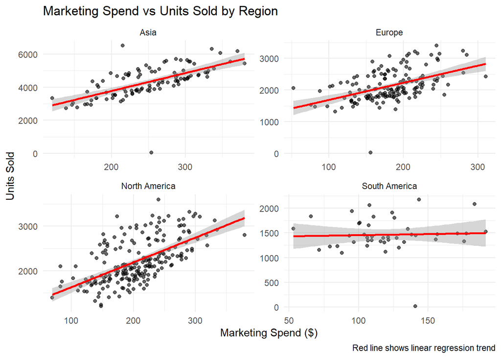

```r
ggplot(global_sales, aes(x = marketing_spend, y = units_sold)) +
  geom_point(alpha = 0.6) +
  geom_smooth(method = "lm", se = TRUE, color = "red") +
  facet_wrap(~ region, scales = "free") +
  labs(
    title = "Marketing Spend vs Units Sold by Region",
    x = "Marketing Spend ($)",
    y = "Units Sold",
    caption = "Red line shows linear regression trend"
  ) +
  theme_minimal()
```

```r
# Calculate correlation by region for additional insight
correlations <- global_sales %>%
  group_by(region) %>%
  summarise(correlation = cor(marketing_spend, units_sold))

print("Correlation between marketing spend and units sold by region:")
```

```
## [1] "Correlation between marketing spend and units sold by region:"
```

```r
print(correlations)
```

```
## # A tibble: 4 × 2
##   region        correlation
##   <chr>               <dbl>
## 1 Asia               0.638
## 2 Europe             0.479
## 3 North America      0.596
## 4 South America      0.0394
```

**Insights:** Asia shows the strongest relationship between marketing spend and units sold (steepest slope and highest correlation), followed by Europe and North America with similar moderate relationships. South America shows the weakest marketing effectiveness, suggesting different market dynamics or customer behavior patterns across regions.

**Question 2.2:** Using the `sale_day_of_week` variable you created in Part 1, calculate the average `units_sold` by day of the week and create a bar plot to visualize this pattern. What pattern emerges regarding sales throughout the week?

```r
daily_averages <- global_sales %>%
  group_by(sale_day_of_week) %>%
  summarise(avg_units_sold = mean(units_sold))

print("Average units sold by day of week:")
```

```
## [1] "Average units sold by day of week:"
```

```r
print(daily_averages)
```

```
## # A tibble: 7 × 2
##   sale_day_of_week avg_units_sold
##   <ord>                     <dbl>
## 1 Sunday                    3284.
## 2 Monday                    2382.
## 3 Tuesday                   2243.
## 4 Wednesday                 2208.
## 5 Thursday                  2300.
## 6 Friday                    2320.
## 7 Saturday                  3114.
```

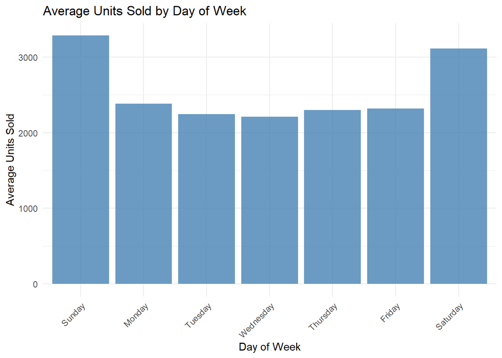

```r
ggplot(daily_averages, aes(x = sale_day_of_week, y = avg_units_sold)) +
  geom_col(fill = "steelblue", alpha = 0.8) +
  labs(
    title = "Average Units Sold by Day of Week",
    x = "Day of Week",
    y = "Average Units Sold"
  ) +
  theme_minimal() +
  theme(axis.text.x = element_text(angle = 45, hjust = 1))
```

**Question 2.3:** Use a box plot to visually identify any outliers in the `units_sold` variable. Then, calculate the Z-score for each observation. According to the Z-score method, any value with an absolute Z-score greater than 3 is considered an extreme outlier. How many extreme outliers do you find?

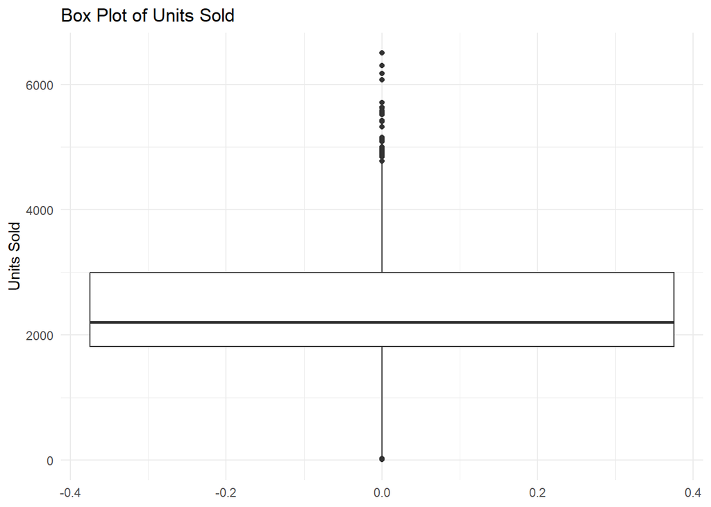

```r
# Box plot for visual outlier identification
ggplot(global_sales, aes(y = units_sold)) +
  geom_boxplot() +
  labs(
    title = "Box Plot of Units Sold",
    y = "Units Sold"
  ) +
  theme_minimal()
```

```r
# Calculate Z-scores
global_sales <- global_sales %>%
  mutate(z_score = scale(units_sold)[,1])

# Find extreme outliers (|Z-score| > 3)
extreme_outliers <- global_sales %>%
  filter(abs(z_score) > 3)

print(paste("Number of extreme outliers (|Z-score| > 3):", nrow(extreme_outliers)))
```

```
## [1] "Number of extreme outliers (|Z-score| > 3): 4"
```

```r
print("Extreme outlier details:")
```

```
## [1] "Extreme outlier details:"
```

```r
print(extreme_outliers %>% select(order_id, units_sold, z_score))
```

```
## # A tibble: 4 × 3
##   order_id units_sold z_score
##   <chr>         <dbl>   <dbl>
## 1 ORD-3817       6070    3.21
## 2 ORD-5915       6299    3.42
## 3 ORD-6368       6500    3.60
## 4 ORD-6184       6175    3.31
```

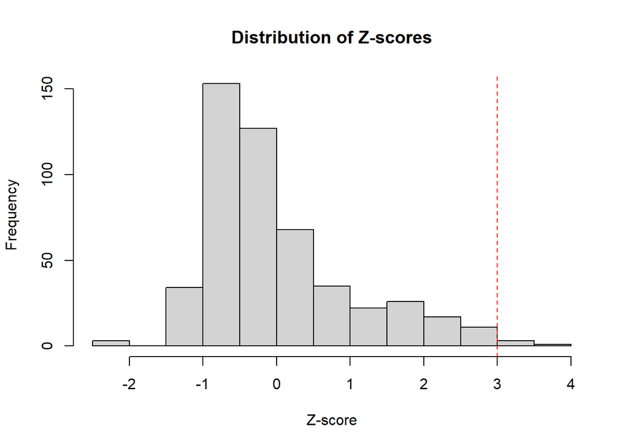

```r
# Show distribution of Z-scores
hist(global_sales$z_score, main = "Distribution of Z-scores", xlab = "Z-score", breaks = 20)
abline(v = c(-3, 3), col = "red", lty = 2)
```

**Short Answer:**

The box plot and Z-score methods may differ because they use different approaches to define outliers. Box plots identify outliers based on the interquartile range (IQR) method (values beyond 1.5*IQR from Q1/Q3), while Z-scores identify outliers based on standard deviations from the mean. For this dataset, I would prefer the Z-score method because it’s more sensitive to the actual distribution and less influenced by skewness, making it better suited for identifying truly anomalous sales figures that might indicate data entry errors or exceptional circumstances.

### Part 3: Engineering for Insight

Your manager wants you to formally model the day of week patterns you saw in `2.2`. Your task is to apply **feature engineering** to create a new binary variable to capture these patterns

**Question 3.1:** Create a new variable that captures the weekly pattern

- *Hint:*It should be a binary variable that relies on your previous insights.

```r
# Based on the pattern observed in 2.2, create a weekend indicator
global_sales <- global_sales %>%
  mutate(is_weekend = if_else(sale_day_of_week %in% c("Saturday", "Sunday"), 1, 0))

# Verify the creation
table(global_sales$is_weekend, global_sales$sale_day_of_week)
```

```
##
##     Sunday Monday Tuesday Wednesday Thursday Friday Saturday
##   0      0     73      67        72       81     59        0
##   1     73      0       0         0        0      0       75
```

**Question 3.2:** What is the average `units_sold` when splitting by your new variable? What does this new feature reveal about sales patterns?

```r
weekend_comparison <- global_sales %>%
  group_by(is_weekend) %>%
  summarise(
    avg_units_sold = mean(units_sold),
    count = n()
  ) %>%
  mutate(period = if_else(is_weekend == 1, "Weekend", "Weekday"))

print("Average units sold by weekend vs weekday:")
```

```
## [1] "Average units sold by weekend vs weekday:"
```

```r
print(weekend_comparison)
```

```
## # A tibble: 2 × 4
##   is_weekend avg_units_sold count period
##        <dbl>          <dbl> <int> <chr>
## 1          0          2291.   352 Weekday
## 2          1          3198.   148 Weekend
```

**Short Answer:**

Creating a binary `is_weekend` feature is more powerful for a predictive model than using raw `sale_date` because it captures the underlying cyclical pattern in a simple, interpretable format. Raw dates have too much granularity and no inherent structure that most algorithms can easily detect. The binary feature reduces complexity while preserving the essential weekly seasonality pattern, making it easier for the model to learn and generalize this important sales driver.

### Part 4: Feature Engineering with Interaction Terms

Based on your initial investigation in Part 2, you noticed that marketing spend seems to have a different effect across regions. Create an **interaction term** that captures this effect for the region where you think marketing spend has the biggest impact

**Question 4.1:** Calculate and print the correlation between your new **interaction term** and `units_sold`.

```r
# Based on Part 2.1 analysis, Asia showed the strongest marketing effectiveness
# Create interaction term for Asia
global_sales <- global_sales %>%
  mutate(
    is_asia = if_else(region == "Asia", 1, 0),
    marketing_spend_asia = marketing_spend * is_asia
  )

# Calculate correlations
correlations_comparison <- global_sales %>%
  summarise(
    marketing_spend_correlation = cor(marketing_spend, units_sold),
    interaction_term_correlation = cor(marketing_spend_asia, units_sold)
  )

print("Correlation comparison:")
```

```
## [1] "Correlation comparison:"
```

```r
print(correlations_comparison)
```

```
## # A tibble: 1 × 2
##   marketing_spend_correlation interaction_term_correlation
##                         <dbl>                        <dbl>
## 1                       0.657                        0.850
```

**Short Answer:**

The interaction term shows a higher correlation with `units_sold` than unconditional `marketing_spend` because it captures the regional heterogeneity in marketing effectiveness. While general marketing spend has a moderate correlation across all regions, the Asia-specific interaction term isolates the strong marketing effect in the most responsive market. This reveals that effective feature engineering isn’t just about creating new variables, but about capturing the conditional relationships and interactions that exist in the data. Models can learn these regional differences more effectively when they’re explicitly encoded as features rather than hidden in the raw data.

### Part 5: Synthesis and Conclusion

**Question 5:** Based on your analysis in Parts 1-4, synthesize your findings and write a brief summary of the key insights you would present to the sales team.

**Short Answer:**

**Next Steps**: Implement a predictive model using these engineered features, establish data quality monitoring processes, and develop region-specific marketing strategies based on effectiveness findings.